# Supuestos de la Regresión Lineal

Reglas invisibles que todos rompen, nadie admite y que hacen escandalizar a los estadísticos teóricos como si fuera herejía

Daniel Barajas Higuera

## Supuestos

[figure not shown]

## ¿Qué es la Regresión Lineal?

- Técnica para modelar la relación entre una variable dependiente (continua) y una o más variables independientes.
- **Tipos:**
  - **Simple:** Una sola variable independiente (p. ej., predecir `price` usando `carat`).
  - **Múltiple:** Varias variables independientes (p. ej., predecir `price` usando `carat`, `cut` y `clarity`).

## Supuestos de la Regresión Lineal

Los supuestos de la regresión lineal aseguran que los resultados del modelo sean válidos y confiables.

- Garantizan que las predicciones sean precisas.
- Evitan resultados sesgados o inexactos.
- Permiten interpretar adecuadamente los coeficientes del modelo.

## Supuestos de la Regresión Lineal

1. **Linealidad**
2. **Homocedasticidad**
3. **Independencia de los errores**
4. **No multicolinealidad**
5. **Normalidad de los errores**

## Supuesto 1: Linealidad

- Existe una relación lineal entre las variables independientes ($x$) y la dependiente ($y$).
- Si no hay linealidad, el modelo no puede capturar correctamente la relación subyacente.
- Evaluación inicial:
  - Gráficos de dispersión ($x$ vs. $y$).

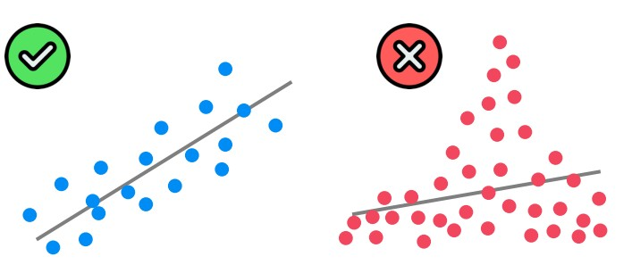

## Supuesto 1: Linealidad (Evaluación)

- **Evaluación adicional:** Dom asume que “más carreras $\Rightarrow$ más problemas familiares” en línea recta. Letty revisa **residuos vs. ajustados** para confirmar que no haya giros de guion. Si aparecen patrones en U o S, se rompe el supuesto de linealidad.
- **Implicación en predicción:** Si la relación no es lineal, el modelo promete control y termina en choque: predicciones sesgadas, fallas al extrapolar, como un derrape mal calculado.

[figure not shown]

## Linealidad en ML

Aquí nadie se muere si la relación no es recta: se lanzan polinomios, interacciones o se cambia de modelo sin drama. La métrica manda, no un altar geométrico.

[figure not shown]

Estadística Clásica

[figure not shown]

Machine Learning

## Supuesto 2: Homocedasticidad

- La varianza de los errores debe ser constante para todos los valores de $x$.
- La heterocedasticidad puede hacer que las predicciones sean menos confiables.
- Evaluación inicial:
  - Gráfico de residuos vs. valores ajustados.

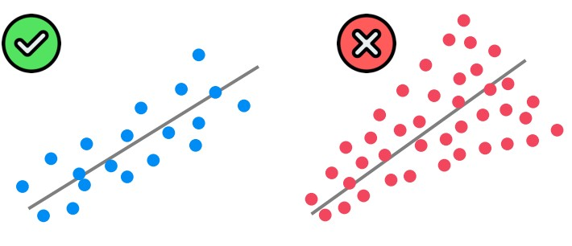

## Supuesto 2: Homocedasticidad (Evaluación)

- **Evaluación adicional:** Brian busca explosiones del mismo tamaño a cualquier velocidad en **residuos vs. ajustados**. Aplica la **prueba de Breusch–Pagan** para verificarlo. Si el nitro explota más a altas velocidades, hay heterocedasticidad.
- **Implicación en predicción:** Con varianza no constante, los intervalos tiemblan: más incertidumbre y menos precisión justo cuando más se necesita.

[figure not shown]

## Homocedasticidad en ML

Varianza desigual: molesta a puristas, no a predictores. Si estorba, se pondera, transforma o modela; mientras tanto, el modelo sigue andando.

[figure not shown]

Estadística Clásica

[figure not shown]

Machine Learning

## Supuesto 3: Independencia de los Errores

- Los errores ($\varepsilon$) deben ser independientes, sin autocorrelación.
- Crucial en datos temporales o secuenciales.
- Evaluación inicial:
  - Gráficos de residuos para identificar patrones.

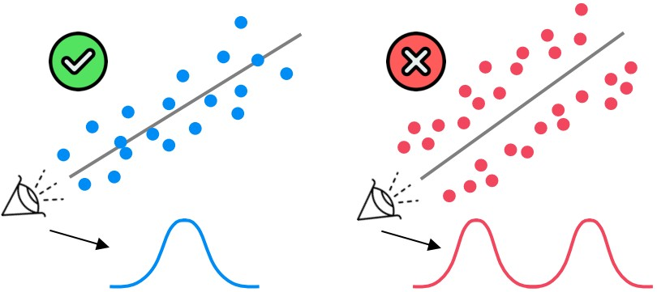

## Supuesto 3: Independencia de los Errores (Evaluación)

- **Evaluación adicional:** Roman verifica con **Durbin–Watson** y correlogramas que los choques de hoy no predigan los de mañana. Si hay autocorrelación, los errores se persiguen en caravana.
- **Implicación en predicción:** Sin independencia, los errores se encadenan. El modelo confunde inercia con señal y repite el mismo derrape una y otra vez.

[figure not shown]

## Independencia en ML

Las observaciones se pegan y se influencian; lo relevante es validar bien para que el brillo del $R^2$ no sea maquillaje barato.

[figure not shown]

Estadística Clásica

[figure not shown]

Machine Learning

## Supuesto 4: Falta de Multicolinealidad

- Las variables independientes no deben estar altamente correlacionadas.
- La colinealidad dificulta determinar el impacto individual de cada variable.
- Evaluación inicial:
  - Matriz de correlación.

[figure not shown]

## Supuesto 4: Falta de Multicolinealidad (Evaluación)

- **Evaluación adicional:** Letty calcula **VIF** y revisa la matriz de correlación. Evita que dos variables sean el mismo auto con pintura distinta. VIF altos significan que los predictores compiten por el mismo rol.
- **Implicación en predicción:** El modelo puede predecir, pero interpretar betas es como conducir con el volante flojo: pequeños cambios en datos mueven grandes cambios en coeficientes.

[figure not shown]

## Multicolinealidad en ML

Coeficientes inestables, sí; pero con regularización, selección o proyecciones, la predicción sigue y las lágrimas se reservan para la interpretación.

[figure not shown]

Estadística Clásica

[figure not shown]

Machine Learning

## Supuesto 5: Normalidad de los Errores

- Los errores deben seguir una distribución normal.
- Relevante para intervalos de confianza y pruebas estadísticas.
- Evaluación inicial:
  - Histogramas y gráficos Q-Q de residuos.

[figure not shown]

## Supuesto 5: Normalidad de los Errores (Evaluación)

- **Evaluación adicional:** La brisa milagrosa no arregla todo: se revisan **histogramas y Q–Q**, y si hace falta, la prueba de **Shapiro–Wilk**. Si los residuos tienen colas pesadas, la distribución no es normal.
- **Implicación en predicción:** La normalidad afecta la inferencia. Predicciones puntuales pueden sobrevivir, pero la confianza en intervalos y tests se desploma.

[figure not shown]

## Normalidad de los errores en ML

Normalidad para predicción: irrelevante. Importa en inferencia; aquí se optimiza desempeño y se ignoran rituales.

[figure not shown]

Estadística Clásica

[figure not shown]

Machine Learning

## Revisión Extra: Valores Atípicos

- Los valores atípicos son observaciones que se desvían mucho del resto de los datos.
- Pueden distorsionar los coeficientes y predicciones.
- Evaluación inicial:
  - Gráficos de dispersión ($x$ vs. $y$).

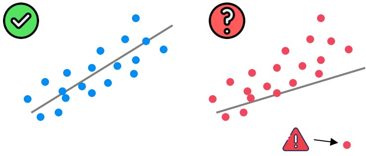

## Valores Atípicos (Evaluación)

- **Evaluación adicional:** Se buscan “stunts imposibles” con **IQR**, leverage o distancia de Cook. Un solo dato extremo puede jalar la recta como si fuera un auto volando en CGI barato.
- **Implicación en predicción:** Los outliers distorsionan betas y reducen precisión. Decisión final: limpiar, robustecer o convertirlo en spin-off dentro del modelo.

[figure not shown]

## Valores Atípicos en Regresión ML

Los outliers no siempre son ruido decorativo: en modelos lineales pueden sesgar los coeficientes y hacer que la recta se incline hacia un solo punto extraño.

- **Impacto en la predicción:** Un dato raro puede inflar el error global y bajar la métrica aunque el resto del ajuste sea bueno.
- **Efecto colateral:** El modelo intenta “complacer” a un caso que jamás se repetirá en test ni en producción.

[figure not shown]

## Por qué tener cuidado en ML

En machine learning robusto los outliers suelen diluirse, pero en regresión lineal básica son como dinamita: un solo punto puede torcer todo el modelo.

- **Decisión práctica:**
  - Si es error de captura → se limpia.
  - Si es real pero extremo → se modela aparte o se usan técnicas robustas.
- **Idea clave:** ignorar un outlier en ML no siempre rompe el modelo, pero dejarlo sin revisar en regresión puede costar métricas, interpretaciones y credibilidad.

[figure not shown]

## Regresión Lineal

[figure not shown]